# Welcome to SI 370: Exploratory Data Analysis

Notebook version 1.3

Note: The course git repo can be accessed via https://gitlab.si.umich.edu/jupyter/si370

## Overview of Today

- Introduction to (part of) the teaching team
- What is Exploratory Data Analysis?
- What is Data Science?
- Syllabus overview
- Getting started with course technology

## About your instructor: Dr. Chris Teplovs

- Originally from Canada
- Ph.D. from University of Toronto
- Postdoctoral Fellow at Copenhagen Business School
- Visiting Associate Research Professor, École Normale Supérieure de Cachan, France
- Lead Developer, Office of Academic Innovation
- Lecturer & Research Scientist, School of Information

[figure not shown]

## Our GSI: Minje Choi

- will join us next week

## Our Instructional Aide: Luke Cheng

- Born and raised in Ann Arbor
- Studying UI/UX and Computer Science
- Enjoys playing tennis, piano and watching sports

[figure not shown]

## What is Exploratory Data Analysis (EDA)?

Wikipedia:

> In statistics, exploratory data analysis (EDA) is an approach to analyzing data sets to summarize their main characteristics, often with visual methods. A statistical model can be used or not, but primarily EDA is for seeing what the data can tell us beyond the formal modeling or hypothesis testing task.

## But really, what is Exploratory Data Analysis?

(TPS)

## What is Data Science?

(TPS)

## EDA is Detective Work

- Tools to find clues, put together a story, identify suspects
- Sometimes clues are accidental or misleading…
  - but it’s critical to find them anyway…
  - because overlooking potential clues could be even worse!

## Goals of Exploratory Data Analysis

- Provide simplified descriptions of what’s happening in (possibly) complex data
- Look below the surface to get new insights
- See interesting behavior through visualization

## We want surprises!

- Exploration & visualization closely linked
- We need pictures with impact: the Goldilocks Principle (not too much, not too little, just right)
- Make comparisons easy

## Some key principles of EDA

- First, find or define “normal”
- Then, compute and visualize differences from the normal
- If studying an event or property in a dataset
- What frequency would you “normally” expect?
- What was the actual frequency observed, compared to the “normal”
- Pick visualizations that emphasize those differences

[figure not shown]

### Preceding images from https://www.kaggle.com/fabiendaniel/predicting-flight-delays-tutorial

## How do we explore?

- Use tools to get different points of view (in order to get a simpler view)
- Many things might not work!
- There is no single right answer
  - There are many ways to approach a body of data
  - Some are better than others
- **Not** finding any patterns one level deeper can still be an important finding!

## How do we find interesting patterns?

- Visualization tools and human pattern recognition (a.k.a. “eyeballing”)
- Analytic/automated methods
  - Statistics
  - Machine Learning

## Skills that you'll learn in SI 370

- Importing and cleaning data
- Summary statistics
- Visualization
- Practical statistics
- Clustering & Classification
- Multidimensional techniques
- Text analytics
- Time series
- Networks

How to apply Python coding and packages to solve the above problems

# Syllabus walk-through

[Syllabus on Google Drive](https://docs.google.com/document/d/1WQL-jEoUnNZdr1_IXdt0Zhm5LXBqQGD0GnGoV8DFRSY/edit)

# Technologies we will be using

## Canvas

- institutional learning management system
- you'll find assignments and grades here

## Jupyter Notebook via Canvas

- Why Jupyter?
  - Interactive, reproducible results, literate programming, REPL (read-eval-print loop)
  - great for data exploration
- Why Jupyter via Canvas?
  - zero-config option for Jupyter (we provide libraries)
  - [Brief video explaining process of using Jupyter in this course](https://drive.google.com/file/d/1LQOMTCmLF0iWDsQt5pB6O8jzDI6KsDFO/view)

## Slack

- group communication tool
- primary communication tool in this course (instead of email)

## Next steps

1. Follow the [invitation link to Slack](https://join.slack.com/t/si370fa2019/shared_invite/enQtNzM4MzA4NDIzMzY1LTE2MzMxMzZjYTUwMjVmYjBhNGRiYmZiYzYwZjk2YzIwNTYxY2E0MmZjMGE3MDM3ZmRmNTI1YjNiNzE4YTgzNjg)
2. Complete the course survey (for points)
3. We'll start working the lab together, share some insights, submit your first notebook for the class, and talk about prepping for next class

## Jupyter via Canvas

- go to Canvas
- click on "Jupyter Notebook"
- click on "si370"
- **DUPLICATE** the file before working on it!

### IMPORTANT: Replace `?` in the following code with your uniqname.

```python
MY_UNIQNAME = 'samcoh'
```

First, let's load the pandas library (which we'll cover in more detail next time):

```python
import pandas as pd
```

We're going to load a bunch of data files from the data/names directory. If you look at that directory you'll see a bunch of files that are names `yobXXXX.txt` where XXXX is a year. The years range from 1880 to 2014, so let's use python's range function to create a list of years:

```python
years = range(1880, 2015) #create an iterator from 1880 and 2014
#range starting at first number ending one short of last number
```

And let's remind ourselves how range works by examining the first and last elements of the list:

```python
print(years[0],years[-1])
```

```
1880 2014
```

The next cell block initializes another empty list (`pieces`), which we append with a pandas DataFrame (which we'll get to next class), the concatenates all those dataframes into one big DataFrame called `df_names`:

```python
pieces = []
for year in years:
    path = 'data/names/yob%d.csv'%year
    frame = pd.read_csv(path)
    frame['year'] = year
    pieces.append(frame)
df_names = pd.concat(pieces, ignore_index=True)
```

Execute the next block . You will see what the DataFrame looks like. It includes the number of births for each name/gender combination for each year. "df_" means DataFrame.

```python
df_names.head()
```

|  | name | gender | birth_count | year |
| --- | --- | --- | --- | --- |
| 0 | Simeon | M | 23 | 1880 |
| 1 | Raoul | M | 7 | 1880 |
| 2 | Lou | M | 14 | 1880 |
| 3 | Myra | F | 83 | 1880 |
| 4 | Alois | M | 10 | 1880 |

We want to visualize the number of births of a specific baby name (e.g., "Mike") across the years. First, execute the following code to select birth records just for "Mike."

```python
df_mike = df_names[(df_names.name == 'Mike') & (df_names.gender == 'M')] #filters out male babies named Mike
```

```python
df_mike.head()
```

|  | name | gender | birth_count | year |
| --- | --- | --- | --- | --- |
| 159 | Mike | M | 95 | 1880 |
| 2741 | Mike | M | 44 | 1881 |
| 5448 | Mike | M | 89 | 1882 |
| 7883 | Mike | M | 73 | 1883 |
| 9709 | Mike | M | 84 | 1884 |

To create a plot, execute the following code. The first line starting with "%" is a command that enables inline plotting for the matplotlib library in Jupyter Notebook. This line needs to be executed only once per session.

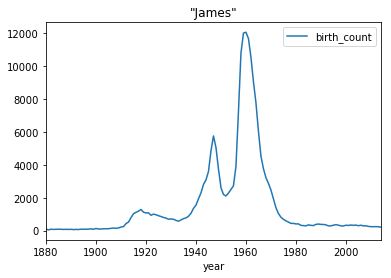

```python
%matplotlib inline
df_mike.plot('year', 'birth_count', title='"James"') #1950s big spike in Mikes
```

## Exercise 1 (4 points): Create a similar graph for all the female babies named "Mike"

Hint: Copy and paste the code above that looks like `df_mike = df_names[(df_names.name == 'Mike') & (df_names.gender == 'M')]` and chamge 'M' to 'F' to get started. You might want to assign the results to another DataFrame

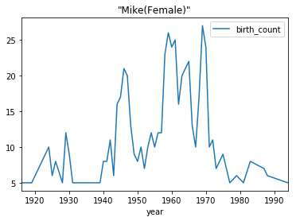

```python
# insert your code here in one or more cells
df_mike_female = df_names[(df_names.name == 'Mike') & (df_names.gender == 'F')]
%matplotlib inline
df_mike_female.plot('year', 'birth_count', title='"Mike(Female)"')
```

## Exercise 2 (3 points): Describe the differences between the two graphs in one or two paragraphs using complete sentences.

Compared to the number of Male babies named Mike between the years 1920 and 1990, Female babies named Mike between have many more spikes and downshifts. The number of Male babies named Mike increased in the 1940s, downshifted and spiked again in the 1950s. After the largest spike in the 1960s, the number of Male babies named Mike became more consistant in the 1980s. Unlike the Number of Male babies Name Mike chart, the number of Female babies Named Mike chart has much more inconsistency starting in the 1920s and continuing through the 1980s up until the year 1990.

## Exercise 3 (3 points): Suggest or hypothesize reasons that may explain the patterns you see in the graphs and the differences between them.

A potential reason as to why the number of Female babies named Mike has much less consistancy than the number of Male babies named Mike is because of cultural trends. In the United States Mike is often thought of as a boys name. Due to this norm it is less common/consistant to name a female "Mike".

## Exercise 4+: Experiment with different names, plots, etc. EXPLORE THE DATA!

```python
# Insert your code here
```

Insert your interpretation here.

# END OF NOTEBOOK

## Remember to submit this file in HTML format via Canvas.